# Agrupamento sobre dados da UFCG

Nessa análise, iremos dividir as Unidades Acadêmicas da UFCG em diferentes grupos, as variáveis utilizadas para fazer esse agrupamento serão exploradas a seguir. Antes de visualizar os dados é importante saber que **percentis** são medidas que dividem a amostra ordenada (por ordem crescente dos dados) em 100 partes, cada uma com uma percentagem de dados aproximadamente igual.

#### Funcionários na UA que não são professores

```r
p = ggplot(ufcg_uas_sumario, aes(x=UORG_LOTACAO,
             y=Outro,
             text = paste("UA:",UORG_LOTACAO,
                            "\nQuantidade:",
                            Outro))) +
     labs(title = "Funcionários que não são professores", y = "Quantidade", x = "UA")+
    theme(legend.position="none") +
  geom_point(colour = "#882C3E") + coord_flip()
ggplotly(p, tooltip = "text")
```

[interactive chart not shown]

#### Professores com carga horária 20h/semana

```r
p = ggplot(ufcg_uas_sumario, aes(x=UORG_LOTACAO,
             y=`Professor 20h`,
             text = paste("UA:",UORG_LOTACAO,
                            "\nQuantidade:",
                            `Professor 20h`))) +
     labs(title = "Professores com carga horária 20h/semana", y = "Quantidade", x = "UA")+
    theme(legend.position="none") +
  geom_point(colour = "#50dd66") + coord_flip()
ggplotly(p, tooltip = "text")
```

[interactive chart not shown]

Aqui, vemos que a maioria das Unidade Acadêmicas não possui nenhum professor com carga horária de 20h/semana, mas a *Unidade Acadêmica de Medicina* chama atenção com 65 professores com essa carga horária.

#### Professores com carga horária 40h/semana na UA, sejam eles Dedicação Exclusiva ou não

```r
p = ggplot(ufcg_uas_sumario, aes(x=UORG_LOTACAO,
             y=`Professor 40h ou DE`,
             text = paste("UA:",UORG_LOTACAO,
                            "\nQuantidade:",
                            `Professor 40h ou DE`))) +
     labs(title = "Professores com carga horária 40h/semana, sejam eles Dedicação Exclusiva ou não", y = "Quantidade", x = "UA")+
    theme(legend.position="none") +
  geom_point(colour = "#ED6471") + coord_flip()
ggplotly(p, tooltip = "text")
```

[interactive chart not shown]

#### 25 percentil da idade dos funcionários *no cargo*

```r
p = ggplot(ufcg_uas_sumario, aes(x=UORG_LOTACAO,
             y=idade_25perc,
             text = paste("UA:",UORG_LOTACAO,
                            "\n25 percentil:",
                            idade_25perc))) +
     labs(title = "25 percentil da idade dos funcionários no cargo", y = "25 Percentil", x = "UA")+
    theme(legend.position="none") +
  geom_point(colour = "#b0b3cc") + coord_flip()
ggplotly(p, tooltip = "text")
```

[interactive chart not shown]

*Exemplo de interpretação: Na Unidade Acadêmica de Engenharia de Materiais, 25% dos funcionários tem 21.73 anos ou menos na profissão.*

#### Idade mediana dos funcionários *no cargo*

```r
p = ggplot(ufcg_uas_sumario, aes(x=UORG_LOTACAO,
             y=idade_mediana,
             text = paste("UA:",UORG_LOTACAO,
                            "\nIdade Mediana:",
                            idade_mediana))) +
     labs(title = "Idade mediana dos funcionários no cargo", y = "Idade mediana", x = "UA")+
    theme(legend.position="none") +
  geom_point(colour = "#5f6694") + coord_flip()
ggplotly(p, tooltip = "text")
```

[interactive chart not shown]

A maioria dos funcionários no cargo está entre 6 e 9.

#### 75 percentil da idade dos funcionários *no cargo*

```r
p = ggplot(ufcg_uas_sumario, aes(x=UORG_LOTACAO,
             y=`idade_75perc`,
             text = paste("UA:",UORG_LOTACAO,
                            "\n75 percentil:",
                            `idade_75perc`))) +
     labs(title = "75 percentil dos funcionários no cargo", y = "75 percentil", x = "UA")+
    theme(legend.position="none") +
  geom_point(colour = "#12131c") + coord_flip()
ggplotly(p, tooltip = "text")
```

[interactive chart not shown]

*Exemplo de interpretação: Na Unidade Acadêmica de Sistemas e computação, 75% dos funcionários tem 22.09 anos ou menos na profissão.*

### Escolha do número K

#### GAP statistic

```r
plot_clusgap = function(clusgap, title="Gap Statistic calculation results"){
    require("ggplot2")
    gstab = data.frame(clusgap$Tab, k=1:nrow(clusgap$Tab))
    p = ggplot(gstab, aes(k, gap)) + geom_line(colour = "#292c40") + geom_point(size=5, colour = "#292c40")
    p = p + geom_errorbar(aes(ymax=gap+SE.sim, ymin=gap-SE.sim), colour = "#292c40", width = .2)
    p = p + ggtitle(title)
    return(p)
}
ufcg.scaled = ufcg_uas_sumario %>%
    select(-UORG_LOTACAO)
gaps <- ufcg.scaled %>%
    clusGap(FUN = kmeans,
            nstart = 20,
            K.max = 8,
            B = 200)
```

```
Clustering k = 1,2,..., K.max (= 8): .. done
Bootstrapping, b = 1,2,..., B (= 200)  [one "." per sample]:
.................................................. 50
.................................................. 100
.................................................. 150
.................................................. 200
```

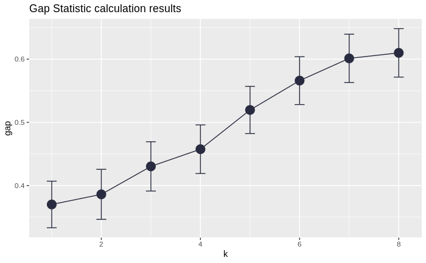

```r
plot_clusgap(gaps)
```

Segundo essa estatística, 8 seria o valor de K ideal.

### K-means

```r
km = kmeans(ufcg.scaled,
            centers = 8,
            nstart = 100)
km
```

```
K-means clustering with 8 clusters of sizes 2, 1, 7, 7, 13, 5, 10, 1

Cluster means:
      Outro Professor 20h Professor 40h ou DE idade_25perc idade_mediana idade_75perc
1 30.500000     0.0000000           46.500000     7.219269     28.304886    38.127489
2 11.000000    65.0000000           37.000000     6.386393      8.801461    28.176119
3  7.000000     0.5714286           34.428571     5.428956     11.838252    25.486980
4  1.571429     0.1428571            6.142857     4.038839      4.762518     8.471618
5  4.230769     2.0769231           28.461538     3.921851      7.211472    10.309259
6  8.200000     7.4000000           57.000000     3.996941      7.373516    13.217078
7  9.400000     0.2000000           20.600000    10.104201     25.871872    31.987283
8  6.000000    42.0000000           11.000000     5.022009      6.424749     7.504201

Clustering vector:
 [1] 4 4 4 4 4 4 7 7 4 7 7 7 5 5 7 5 7 5 7 7 7 5 5 5 3 5 3 5 3 3 5 5 3 5 3 1 5 3 1 8 6 6 6 6 6 2

Within cluster sum of squares by cluster:
[1]  68.52542   0.00000 579.80948 782.09812 894.02179 482.46484 994.76094   0.00000
 (between_SS / total_SS =  86.8 %)

Available components:

[1] "cluster"      "centers"      "totss"        "withinss"     "tot.withinss" "betweenss"    "size"
[8] "iter"         "ifault"
```

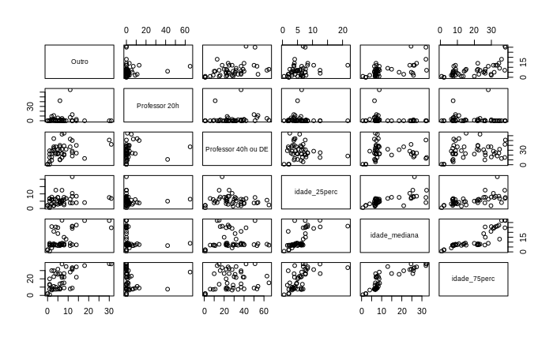

```r
plot(ufcg.scaled)
```